# R Cheatsheet for WSR

Klinkenberg

7/5/2017

## Intro

In R is het mogelijk om allerlei berekeningen uit te voeren en de resultaten hiervan op te slaan in zogenoemde variabelen. Hieronder is een lijstje weergegeven waarin de meest gebruikte statistische functies staan die we in deze cursus zullen gebruiken. Bij elke statistische functie staat een voorbeeld waarin deze wordt toegepast. De variabelen “a” en “x” worden bij de eerste twee voorbeelden gemaakt en worden daarna telkens gebruikt als voorbeeld waarop de statistische functie wordt toegepast.

### Cheatsheet

| Symbool | R | Voorbeeld | Resultaat | Uitleg |
| --- | --- | --- | --- | --- |
| = | a=9 | 9 | Een getal toekennen aan een variabele |  |
| c() | x=c(1,2,3) | 1, 2, 3 | Meerdere getallen toekennen aan een variabele. |  |
| = | == | a==7 | FALSE | Logische statement “a is gelijk aan 7” |
| - | - | x-1 | 0, 1, 2 | aftrekken |
| + | + | x+1 | 2, 3, 4 | optellen |
| x | * | x*2 | 2, 4, 6 | vermenigvuldigen |
| : | / | x/2 | 0.5, 1, 1.5 | delen door |
| $\sqrt{}$ | sqrt() | sqrt(a) | 3 | wortel |
| $x^2$ | ^ | x^2 | 1, 4, 9 | kwadraat |
| $\bar{x}$ | mean() | mean(x) | 2 | gemiddelde |
| N | length() | length(x) | 3 | geeft het aantal getallen in de variabele terug |
| $\sum$ | sum() | sum(x) | 6 | telt alle getallen in de variabele bij elkaar op |
| $s^2$ | var() | var(x) | 1 | geeft de variantie van de getallen in de variabele |
| $s$ | sd() | sd(x) | 1 | geeft de standaarddeviatie van de getallen in de variabele |
| cbind() | cbind(x,a,b=x-a) | zie hieronder | zet variabelen achter elkaar in een tabel. Wanneer variabelen een kortere lengte hebben worden zij herhaald. |  |
| visualize.t() | visualize.t(2,16,“upper”) | zie hieronder | geeft de p-waarde weer in een t-verdeling bij t>2 met 16 vrijheidsgraden |  |
|  | visualize.t(2,16,“lower”) |  | geeft de p-waarde weer in een t-verdeling bij t<2 met 16 vrijheidsgraden |  |
|  | visualize.t(c(-2,2),16,“tails”) |  | geeft de p-waarde van de tweezijdige t-toets bij t<-2 of t>2 met 16 vrijheidsgraden weer |  |
| visualize.chisq() | visualize.chisq(4,1,“upper”) |  | geeft de p-waarde weer in een verdeling bij $\chi^2$>4 met 1 vrijheidsgraad |  |
| visualize.f() | visualize.f(3,2,10,“upper”) |  | geeft de p-waarde weer in een F-verdeling bij F>3 en df(2,10) |  |
| subset() | subset(p,group==1)$y |  | geeft aan dat je uit dataset “p” enkel de scores op y van groep 1 wil |  |
| ls() | ls() | “a” “x” | Geeft een overzicht van de variabelen die je hebt aangemaakt |  |

#### Resultaat cbind(x,a,b=x-a)

```
##      x a  b
## [1,] 1 9 -8
## [2,] 2 9 -7
## [3,] 3 9 -6
```

### Visualize

Om visualize te kunnen gebruiken moet je de onderste twee regels in R plakken en runnen.

```r
if(!"visualize" %in% installed.packages()) { install.packages("visualize") };
library("visualize");
```

#### Voorbeeld toepassing

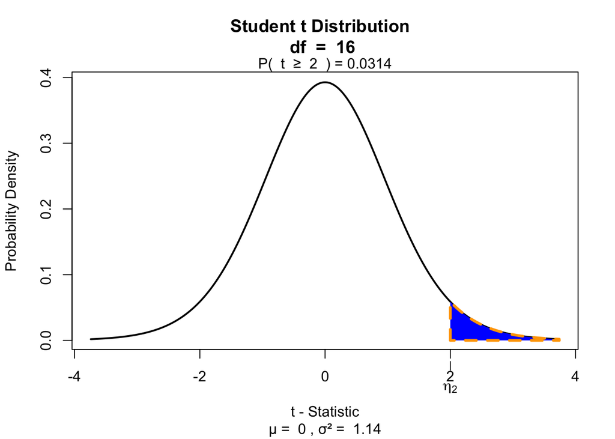

```r
library(visualize);
visualize.t(2,16,"upper");
```

### Voorbeelden

#### Getallen toekennen aan Variabelen

```r
x1=c(5,3,7,4);
x2=c(7,6,6,4);
a=2;
b=c(1,2);
```

#### Rekenen met variabelen

Variabelen met een gelijke lengte kan je van elkaar aftrekken. Hieronder wordt bijvoorbeeld het 1e getal van x2 afgetrokken van de 1e getal van x1, het tweede getal van x2 wordt afgetrokken van het tweede getal van x1, etc.

```r
x1-x2
```

```
## [1] -2 -3  1  0
```

Wanneer variabelen een verschillende lengte hebben worden de getallen / het getal van de kortste variabele herhaald zodat de lengte gelijk wordt aan die van de langere variabele

```r
x1-a;
```

```
## [1] 3 1 5 2
```

```r
x1-b;
```

```
## [1] 4 1 6 2
```